# Lab: Simulation and the Central Limit Theorem

## Introduction

In your coursework, you learned a bit about the **Central Limit Theorem**.

In this lab, you will use **simulation** to illustrate this concept.

## Part One: Summarize fake data

1. Create a new dataset containing four variables: one that comes from a **Normal** distribution, one from a **Uniform** distribution, one from a **Binomial** distribution, and one from an **exponential** distribution.

You should **not** use the default options for these distributions; e.g., your Normal data should not have a mean of 0 or a standard deviation of 1, and your Binomial data should not have a probability of 0.5.

Your data should have **30 rows**.

(We did *not* learn about the exponential distribution in lecture; I would like you to figure out the `r, d, p, q` functions for this new distribution yourself.)

Feel free to make up silly names for your fake variables, and/or to add fake names or other labels to this dataset, if you are inspired.

```r
candy_ratings <- tibble(
  red_vines = rnorm(30, 100, 5),
  twizzlers = runif(30, 60, 70),
  reeses = rbinom(30, 100, .8),
  hersheys = rexp(30, .05)
)
```

2. Calculate the **mean** and **standard deviation** for each of your four variables.

```r
candy_ratings %>%
  summarize_all(funs(mean, sd))
```

```
## # A tibble: 1 x 8
##   red_vines_mean twizzlers_mean reeses_mean hersheys_mean red_vines_sd
##            <dbl>          <dbl>       <dbl>         <dbl>        <dbl>
## 1           99.8           64.8        80.2          20.7         5.11
## # ... with 3 more variables: twizzlers_sd <dbl>, reeses_sd <dbl>,
## #   hersheys_sd <dbl>
```

3. Now repeat steps (1) and (2), using the same distributions, but instead make **1000** rows in your dataset.

```r
candy_ratings <- tibble(
  red_vines = rnorm(1000, 100, 5),
  twizzlers = runif(1000, 60, 70),
  reeses = rbinom(1000, 100, .8),
  hersheys = rexp(1000, .05)
)


candy_ratings %>%
  summarize_all(funs(mean, sd))
```

```
## # A tibble: 1 x 8
##   red_vines_mean twizzlers_mean reeses_mean hersheys_mean red_vines_sd
##            <dbl>          <dbl>       <dbl>         <dbl>        <dbl>
## 1           100.           65.1        80.0          19.5         4.88
## # ... with 3 more variables: twizzlers_sd <dbl>, reeses_sd <dbl>,
## #   hersheys_sd <dbl>
```

Comment on the means and standard deviations in this section, as compared to in (2).

```
They are about the same in both cases, because the data is drawn from the
same distribution, regardless of the number of samples.
```

4. Make a histogram for each of your four variables, with the underlying distribution overlayed on top.

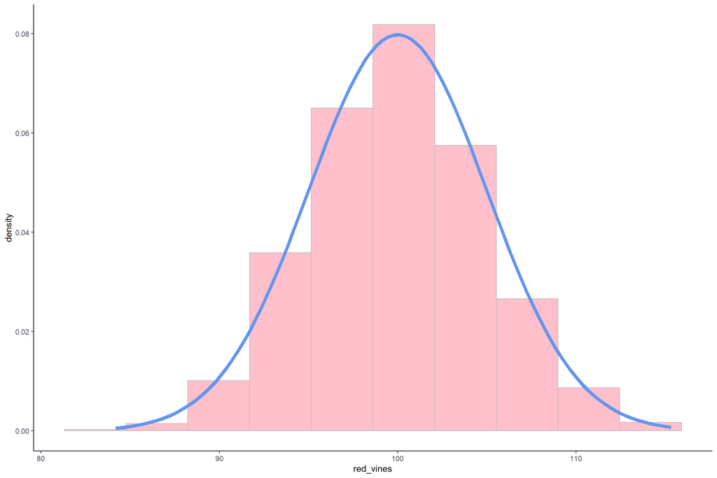

```r
candy_ratings %>%
  ggplot(aes(x = red_vines)) +
  geom_histogram(aes(y = ..density..),
                 col = "grey", fill = "pink",
                 bins = 10) +
  stat_function(fun = dnorm,
                args = list(100, 5),
                col = "cornflowerblue",
                lwd = 2) +
  theme_classic()
```

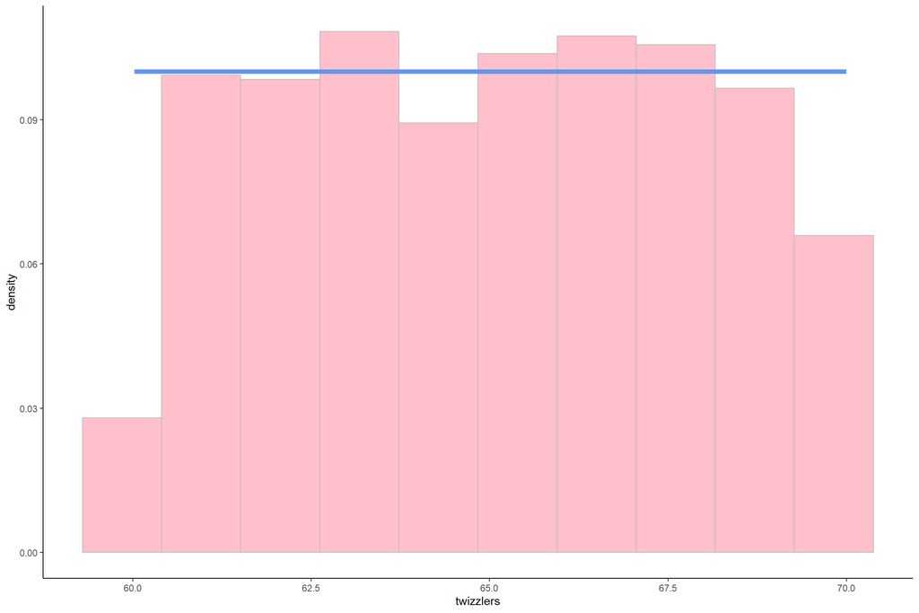

```r
candy_ratings %>%
  ggplot(aes(x = twizzlers)) +
  geom_histogram(aes(y = ..density..),
                 col = "grey", fill = "pink",
                 bins = 10) +
  stat_function(fun = dunif,
                args = list(60, 70),
                col = "cornflowerblue",
                lwd = 2) +
  theme_classic()
```

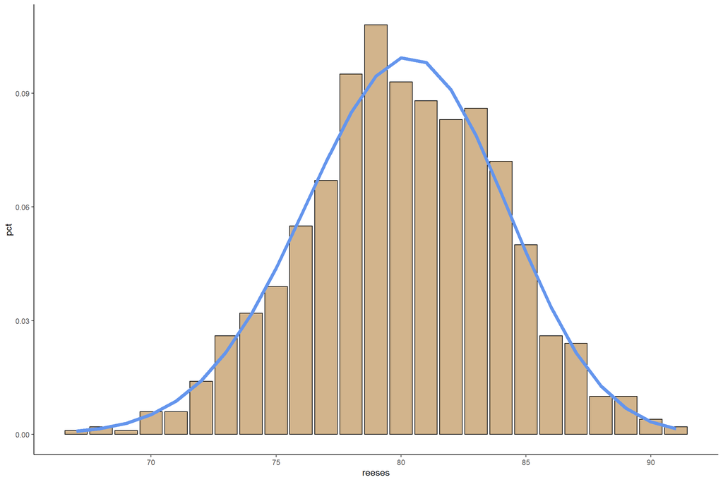

```r
candy_ratings %>%
  count(reeses) %>%
  mutate(
    pct = n/sum(n),
    dbin = dbinom(reeses, 100, .8)
  ) %>%
  ggplot() +
  geom_col(aes(x = reeses, y = pct),
                 col = "black", fill = "tan") +
  geom_line(aes(x = reeses, y = dbin),
                col = "cornflowerblue",
                lwd = 2) +
  theme_classic()
```

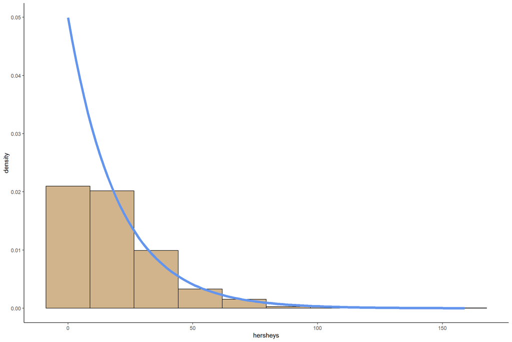

```r
candy_ratings %>%
  ggplot(aes(x = hersheys)) +
  geom_histogram(aes(y = ..density..),
                 col = "black", fill = "tan",
                 bins = 10) +
  stat_function(fun = dexp,
                args = list(.05),
                col = "cornflowerblue",
                lwd = 2) +
  theme_classic()
```

## Part Two: Generating sample means

1. Write a function called `sample_mean`. This function should take as input a vector `vec` and an integer `n`. It should take a random sample of size `n` from `vec`, then calculate and return the mean of that subsample.

```r
sample_mean <- function(vec, n) {

  subsample <- sample(vec, n)
  mean(subsample, na.rm = TRUE)


}

sample_mean(1:10, 5)
```

```
## [1] 4.6
```

2. Write a function called `many_sample_means`. This function should take as input a vector `vec`, an integer `n`, and an integer `reps`. It should perform the `sample_mean` process many times (`reps`) and return a vector of the results.

```r
many_sample_means <- function(vec, n, reps = 1000) {

  replicate(reps, sample_mean(vec, n))

}

many_sample_means(1:10, 5, 10)
```

```
##  [1] 4.0 4.8 4.6 7.6 7.0 6.0 7.6 4.6 6.2 5.2
```

3. Write a function called `sample_means_ns`. This function should take as input a vector `vec` and an integer `reps`, and a vector `ns`. It should perform the `many_sample_means` process for each of the values in the `ns` vector. It should return a **data frame** with the results.

```r
sample_means_ns <- function(vec, ns, reps = 1000) {

  my_means <- map(ns, ~many_sample_means(vec, .x, reps))

  tibble(
    sample_mean = unlist(my_means),
    n = rep(ns, each = reps)
  )

}

sample_means_ns(1:10, 5:7, 10)
```

```
## # A tibble: 30 x 2
##    sample_mean     n
##          <dbl> <int>
##  1         6.6     5
##  2         4.4     5
##  3         5.2     5
##  4         5       5
##  5         6.4     5
##  6         6.4     5
##  7         5.8     5
##  8         5.2     5
##  9         4.8     5
## 10         5.8     5
## # ... with 20 more rows
```

Include the following in your final R Markdown to show your functions work:

```r
vec <- runif(1000)

sample_mean(vec, 50)
many_sample_means(vec, reps = 10, n = 50)
sample_means_ns(vec, reps = 10, ns = c(5, 50, 500))
```

[output not shown]

## Part Three: Putting it all together

For any **two** of the four variables in your fake dataset from Part One, do the following:

1. Use your `many_sample_means` function with `reps = 1000` and `n = 10`.

```r
twiz_means <- candy_ratings %>%
  pull(twizzlers) %>%
  many_sample_means(n = 10, reps = 1000)

hersh_means <- candy_ratings %>%
  pull(hersheys) %>%
  many_sample_means(n = 10, reps = 1000)
```

```
(a) Make histograms of each of your results (no overlay required)
```

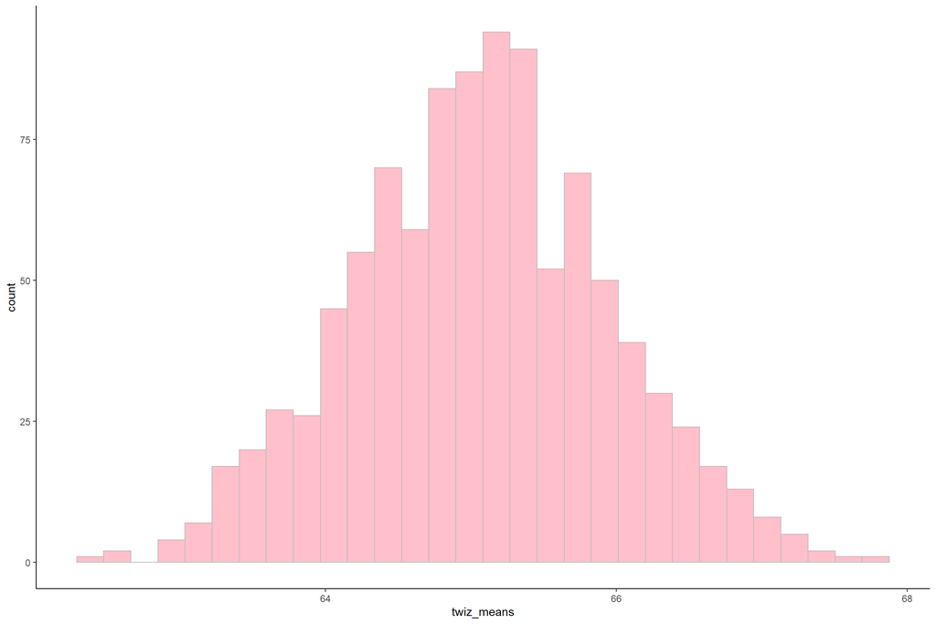

```r
ggplot(, aes(x = twiz_means)) +
  geom_histogram(col = "grey", fill = "pink") +
  theme_classic()
```

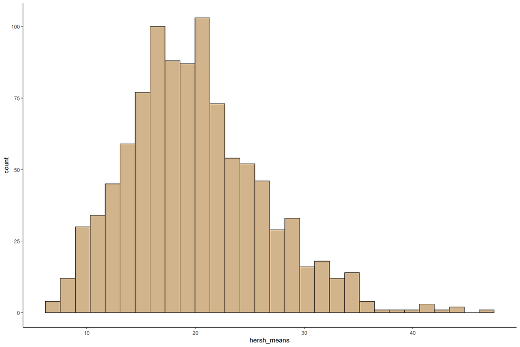

[output not shown]

```r
ggplot(, aes(x = hersh_means)) +
  geom_histogram(col = "black", fill = "tan") +
  theme_classic()
```

```r
mean(twiz_means)
```

```
## [1] 65.0659
```

```r
sd(twiz_means)
```

```
## [1] 0.8757318
```

```r
mean(hersh_means)
```

```
## [1] 19.93998
```

```r
sd(hersh_means)
```

```
## [1] 6.30734
```

2. Use your `many_sample_means` function with `reps = 1000` and `n = 500`.

```r
twiz_means <- candy_ratings %>%
  pull(twizzlers) %>%
  many_sample_means(n = 500, reps = 1000)

hersh_means <- candy_ratings %>%
  pull(hersheys) %>%
  many_sample_means(n = 500, reps = 1000)
```

```
(a) Make histograms of each of your results (no overlay required)
```

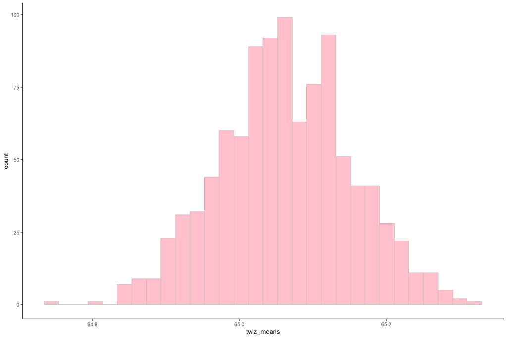

```r
ggplot(, aes(x = twiz_means)) +
  geom_histogram(col = "grey", fill = "pink") +
  theme_classic()
```

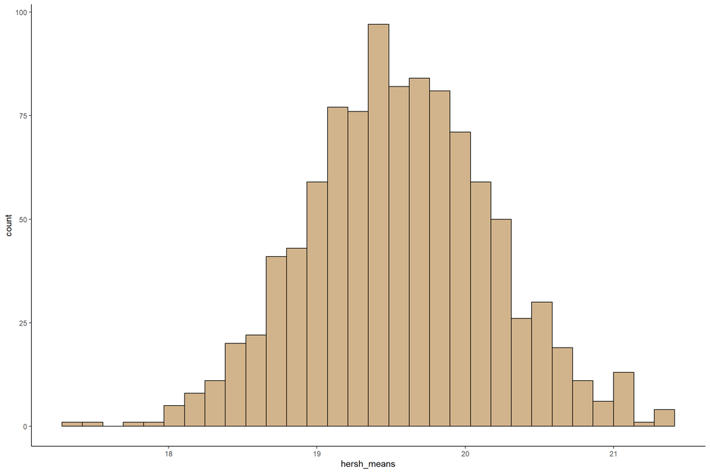

[output not shown]

```r
ggplot(, aes(x = hersh_means)) +
  geom_histogram(col = "black", fill = "tan") +
  theme_classic()
```

```r
mean(twiz_means)
```

```
## [1] 65.06274
```

```r
sd(twiz_means)
```

```
## [1] 0.08991829
```

```r
mean(hersh_means)
```

```
## [1] 19.5585
```

```r
sd(hersh_means)
```

```
## [1] 0.6267819
```

3. Comment on the differences or similarities between (1) and (2)

```
The means of the sample means are the same in both cases.
The standard deviations of the sample means are smaller in (2), by a factor
of about 10.
The histogram of the means from the exponential data (Hershey's) is more symmetric
and bell-curve shaped in (2).
```

4. Use your `sample_means_ns` function to try a variety of values of `n`.  
   Calculate the standard deviation of the results for each value of `n`. Make a plot that shows how the standard deviation of the sample means changes with `n`.

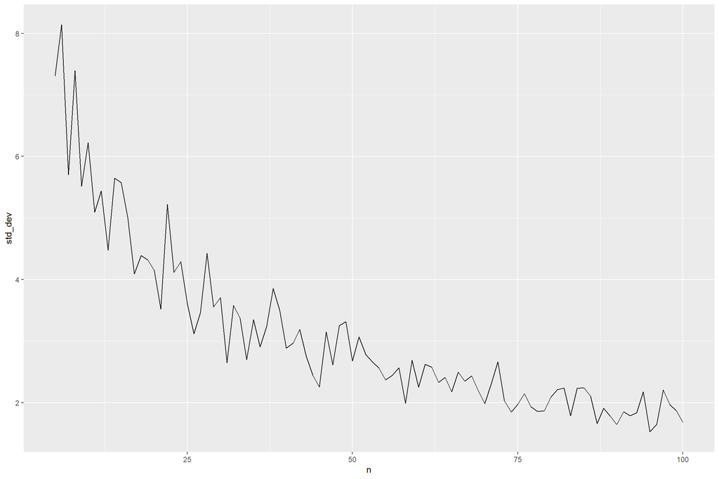

```r
candy_ratings %>%
  pull(hersheys) %>%
  sample_means_ns(ns = 5:100, reps = 50) %>%
  group_by(n) %>%
  summarize(std_dev = sd(sample_mean)) %>%
  ggplot(aes(x = n, y = std_dev)) +
  geom_line()
```

## Part Four: Appreciate the CLT

You have been told that the amount of time you have to wait for a bus from Cal Poly to Downtown SLO is `exponential(0.02)`; that is, that the true average wait time is about 50 minutes.

You think this might be a lie. In the last 30 days, you have waited for the bus for 55 minutes on average.

If the bus system is telling the truth about the `exponential(0.02)` distribution, how unlucky were you this month?

1. Simulate 10000 random values from the `exponential(0.02)` distribution. Use your `many_sample_means` on these values, with `n = 30` and `reps = 1000`. How many times did your sample mean exceed 55?

```r
rand_vals <- rexp(10000, 0.02)

my_sample_means <- many_sample_means(rand_vals, n = 30, reps = 1000)

sum(my_sample_means > 55)
```

```
## [1] 273
```

2. Use the Central Limit Theorem to assume that a sample mean of exponentially distributed values is Normally distributed, with mean $50$ and standard deviation $50/\sqrt{n}$. Find the probability that a sample mean exceeds 55.

```r
1 - pnorm(55, mean = 50, sd = 50/sqrt(30))
```

```
## [1] 0.2919412
```

3. Comment on (1) and (2). Were the answers similar? Do you believe that bus wait times really are distributed `exponential(0.02)`?

```
Yes, the answers were similar!

It looks like the chances of an average monthly wait time of 55 minutes or more
is about 29% - so it's not too surprising.  It's plausible that the proposed
distribution of wait times is true.
```